# Assessment 1 Repro

JuanPMarino

11/10/2020

## Resume

This is an R Markdown document about the peer assessment in the Reproducible Research course. ##Loading the libraries

```r
library(ggplot2)
```

##Loading and trasnsforming the data. Loading and transforming the data for further analisys, the transform happens in the time system of the data set.

```r
data <- read.csv('activity.csv')
data <- transform(data, date = as.Date(date))
```

##The mean total steps per day Adding the column of the total steps per day

```r
steps_day <- aggregate(steps ~ date, data, sum, na.rm = TRUE)
```

Creating the histogram required about the mean steps taken per day.

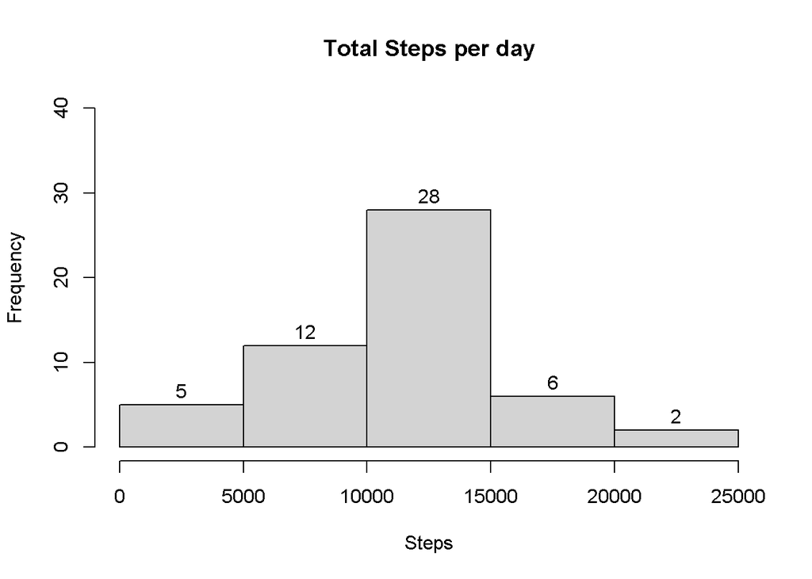

```r
hist(steps_day$steps, main = "Total Steps per day", xlab = "Steps", ylim = c(0,40), labels = TRUE)
```

The mean:

```r
mean(steps_day$steps)
```

```
## [1] 10766.19
```

Median:

```r
median(steps_day$steps)
```

```
## [1] 10765
```

##The average daily activity Aggregate data for time series plot, remove NA’s

```r
mean_steps_interval <- aggregate(steps ~ interval, data, mean, na.rm = TRUE)
```

Create the time series plot

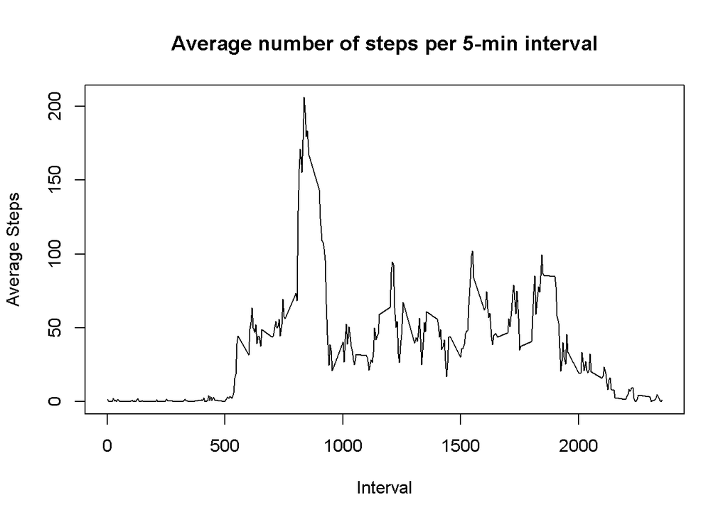

```r
plot(mean_steps_interval$interval, mean_steps_interval$steps, type = "l", main = "Average number of steps per 5-min interval", xlab = "Interval", ylab = "Average Steps")
```

Max interval between steps

```r
max_interval <- mean_steps_interval$interval[which(mean_steps_interval$steps == max(mean_steps_interval$steps))]
max_interval
```

```
## [1] 835
```

##With Missing values Calculate and report the total number of missing values in the dataset,How many there are.

```r
sum(is.na(data))
```

```
## [1] 2304
```

the replace of the NA’S could be done by each NA in the step, replace it by the mean of the interval to fit redundancy.

```r
Rep_data <- data
for (i in 1:length(Rep_data$steps)) {
  if (is.na(Rep_data$steps[i])) {
    Rep_data$steps[i] <- mean_steps_interval$steps[mean_steps_interval$interval == Rep_data$interval[i]]
  }
}
imp_steps_per_day <- aggregate(steps ~ date, Rep_data, sum, na.rm = TRUE)
sum(is.na(imp_steps_per_day$steps))
```

```
## [1] 0
```

Check the changes into the histogram

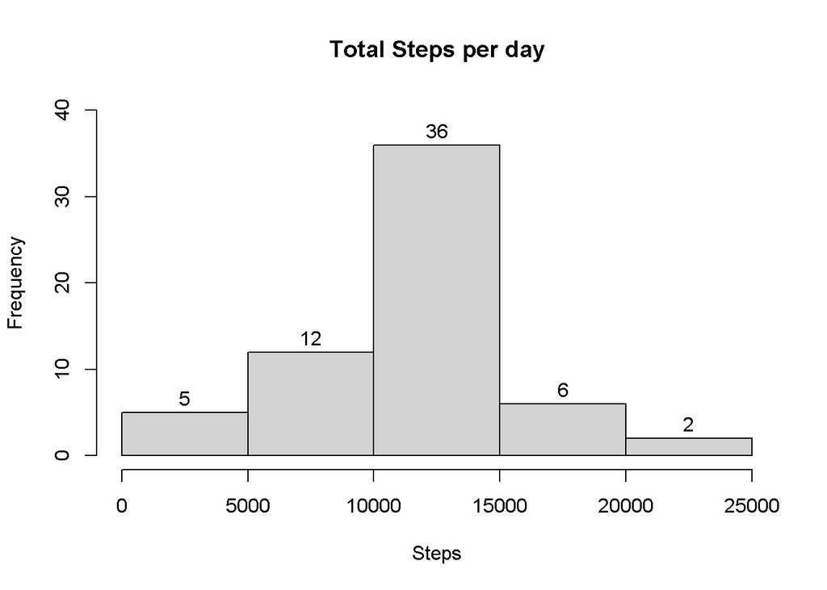

```r
hist(imp_steps_per_day$steps, main = "Total Steps per day", xlab = "Steps", ylim = c(0,40), labels = TRUE)
```

```r
Rep_data$date <- as.Date(Rep_data$date)
Rep_data$wkdy <- "weekday"
Rep_data$wkdy[weekdays(Rep_data$date) == "Saturday" | weekdays(Rep_data$date) == "Sunday"] <- "weekend"
Rep_data$wkdy <- as.factor(Rep_data$wkdy)
Rep_data_interval <- aggregate(steps ~ interval + wkdy, Rep_data, mean, na.rm = TRUE)
```

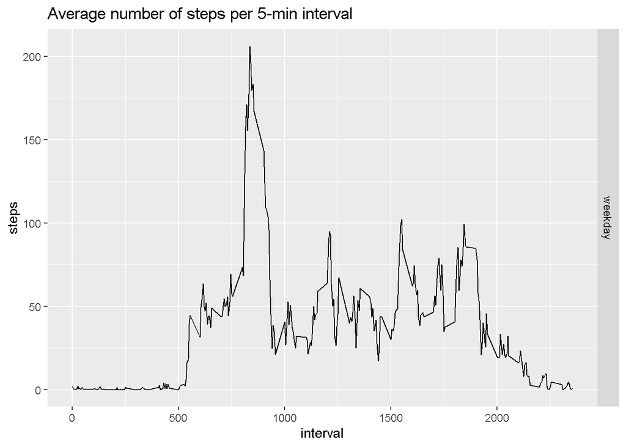

```r
g <- ggplot(Rep_data_interval, aes(interval, steps))
g + facet_grid(wkdy~.) + geom_line() + ggtitle("Average number of steps per 5-min interval")
```